# Do We Really Know the WTO Increases Trade?

This note reproduce the results of paper “Do We Really Know the WTO Increases Trade?” by ANDREW K. ROSE.

Data is provided by the author at http://faculty.haas.berkeley.edu/arose/RecRes.htm.

## Read In Data

```r
options(warn = -1)
library(haven)
data4web <- read_dta("./data4web.dta")
```

```r
print(colnames(data4web))
```

```
 [1] "cty1"     "cty2"     "year"     "pairid"   "landl"    "island"   "border"   "comlang"  "comcol"
[10] "comctry"  "colony"   "curcol"   "custrict" "ltrade"   "regional" "lareap"   "ldist"    "lrgdp"
[19] "lrgdppc"  "rta"      "sasia1"   "ssafr1"   "easia1"   "highi1"   "latca1"   "least1"   "lowin1"
[28] "menaf1"   "midin1"   "sasia2"   "ssafr2"   "easia2"   "highi2"   "latca2"   "least2"   "lowin2"
[37] "menaf2"   "midin2"   "carib1"   "carib2"   "join1"    "join2"    "onein"    "bothin"   "nonein"
[46] "found1"   "found2"   "years1"   "years2"   "minyrs"   "maxyrs"   "gsp"      "ecd"      "usi"
[55] "naf"      "car"      "pat"      "anz"      "cac"      "mer"      "ase"      "spr"      "cty1name"
[64] "cty2name"
```

```r
head(data4web)
```

| cty1 | cty2 | year | pairid | landl | island | border | comlang | comcol | comctry | colony | curcol | custrict | ltrade | regional | lareap | ldist | lrgdp | lrgdppc | rta | sasia1 | ssafr1 | easia1 | highi1 | latca1 | least1 | lowin1 | menaf1 | midin1 | sasia2 | … |
| --- | --- | --- | --- | --- | --- | --- | --- | --- | --- | --- | --- | --- | --- | --- | --- | --- | --- | --- | --- | --- | --- | --- | --- | --- | --- | --- | --- | --- | --- | --- |
| 111 | 112 | 1948 | 765 | 0 | 0 | 0 | 1 | 0 | 0 | 1 | 0 | 0 | 16.84779 | 0 | 28.48858 | 8.373431 | 53.84062 | 17.30518 | 0 | 0 | 0 | 0 | 1 | 0 | 0 | 0 | 0 | 0 | 0 | … |
| 111 | 112 | 1949 | 765 | 0 | 0 | 0 | 1 | 0 | 0 | 1 | 0 | 0 | 16.86135 | 0 | 28.48858 | 8.373431 | 53.81392 | 17.25539 | 0 | 0 | 0 | 0 | 1 | 0 | 0 | 0 | 0 | 0 | 0 | … |
| 111 | 112 | 1950 | 765 | 0 | 0 | 0 | 1 | 0 | 0 | 1 | 0 | 0 | 16.76863 | 0 | 28.48858 | 8.373431 | 54.25347 | 17.67255 | 0 | 0 | 0 | 0 | 1 | 0 | 0 | 0 | 0 | 0 | 0 | … |
| 111 | 112 | 1951 | 765 | 0 | 0 | 0 | 1 | 0 | 0 | 1 | 0 | 0 | 17.17045 | 0 | 28.48858 | 8.373431 | 54.34528 | 17.74432 | 0 | 0 | 0 | 0 | 1 | 0 | 0 | 0 | 0 | 0 | 0 | … |
| 111 | 112 | 1952 | 765 | 0 | 0 | 0 | 1 | 0 | 0 | 1 | 0 | 0 | 17.04775 | 0 | 28.48858 | 8.373431 | 54.35128 | 17.73057 | 0 | 0 | 0 | 0 | 1 | 0 | 0 | 0 | 0 | 0 | 0 | … |
| 111 | 112 | 1953 | 765 | 0 | 0 | 0 | 1 | 0 | 0 | 1 | 0 | 0 | 17.00041 | 0 | 28.48858 | 8.373431 | 54.44038 | 17.80010 | 0 | 0 | 0 | 0 | 1 | 0 | 0 | 0 | 0 | 0 | 0 | … |

## Correlation

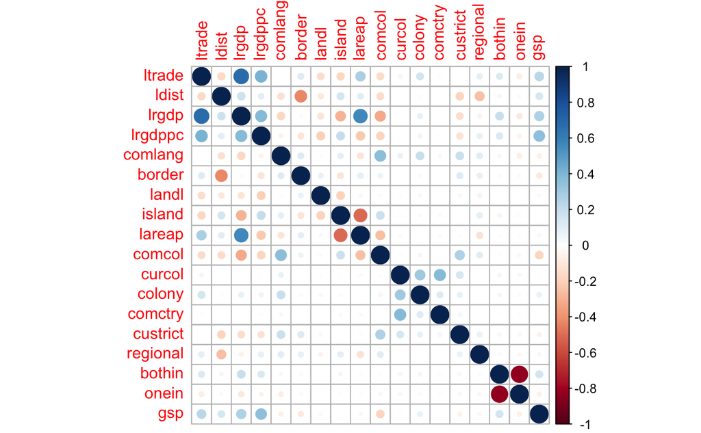

```r
options(warn = -1)
data4web_corr <- cor(data4web[c("ltrade", "ldist", "lrgdp", "lrgdppc", "comlang", "border", "landl", "island", "lareap", "comcol", "curcol", "colony", "comctry", "custrict", "regional", "bothin", "onein", "gsp")], method = "pearson")
library(corrplot)
corrplot(data4web_corr)
```

The key GATT/WTO and GSP variables are not highly correlated with most of the gravity variables. The only exception is the GSP dummy, which is positively correlated with both real GDP variables, as one might expect (given that richer countries are those that extend the GSP concessions). In other words, multicollinearity is not a problem for the coefficients of interest.

## Regression

$$\begin{aligned}
\ln \left(X_{i j t}\right)=& \beta_{0}+\beta_{1} \ln D_{i j}+\beta_{2} \ln \left(Y_{i} Y_{j}\right)_{t} \\
&+\beta_{3} \ln \left(Y_{i} Y_{j} / P o p_{i} P o p_{j}\right)_{t}+\beta_{4} Lang_{i j} \\
&+\beta_{5} Cont_{i j}+\beta_{6} L a n d l_{i j}+\beta_{7} I s l a n d_{i j} \\
&+\beta_{8} \ln \left(A r e a_{i} A r e a_{j}\right)+\beta_{9} C o m C o l_{i j} \\
&+\beta_{10} C u r C o l_{i j t}+\beta_{11} C o l o n y_{i j} \\
&+\beta_{12} C o m N a t_{i j}+\beta_{13} C U_{i j t} \\
&+\beta_{14} F T A_{i j t}+\Sigma_{t} \phi_{t} T_{t}+\gamma_{1} B o t h i n_{i j t} \\
&+\gamma_{2} O n e i n_{i j t}+\gamma_{3} G S P_{i j t}+\varepsilon_{i j t}
\end{aligned}$$

```r
library(plm)
library(lmtest)
library(estimatr)
library(nlme)
library(prais)
```

## BenchMark

Use the augmented gravity model, estimated with ordinary least squares, year fixed effects, and robust standard errors over the full sample.

```r
gravityMod <- plm(ltrade ~ ldist + lrgdp + lrgdppc + comlang + border + landl + island + lareap + comcol + curcol + colony + comctry + custrict + regional + bothin + onein + gsp, data=data4web, index = c("pairid", "year"), effect = "time", model = "within")
summary(gravityMod)
```

```
Oneway (time) effect Within Model

Call:
plm(formula = ltrade ~ ldist + lrgdp + lrgdppc + comlang + border +
    landl + island + lareap + comcol + curcol + colony + comctry +
    custrict + regional + bothin + onein + gsp, data = data4web,
    effect = "time", model = "within", index = c("pairid", "year"))

Unbalanced Panel: n = 12150, T = 1-52, N = 234597

Residuals:
     Min.   1st Qu.    Median   3rd Qu.      Max.
-24.23345  -0.98142   0.14527   1.18478  10.17051

Coefficients:
           Estimate Std. Error   t-value  Pr(>|t|)
ldist    -1.1190287  0.0061127 -183.0660 < 2.2e-16 ***
lrgdp     0.9159030  0.0025737  355.8693 < 2.2e-16 ***
lrgdppc   0.3214132  0.0038598   83.2711 < 2.2e-16 ***
comlang   0.3125448  0.0110419   28.3054 < 2.2e-16 ***
border    0.5257054  0.0266441   19.7306 < 2.2e-16 ***
landl    -0.2705915  0.0093218  -29.0278 < 2.2e-16 ***
island    0.0419270  0.0094579    4.4330 9.296e-06 ***
lareap   -0.0967329  0.0020337  -47.5640 < 2.2e-16 ***
comcol    0.5845614  0.0161904   36.1054 < 2.2e-16 ***
curcol    1.0751459  0.1067122   10.0752 < 2.2e-16 ***
colony    1.1638377  0.0311729   37.3350 < 2.2e-16 ***
comctry  -0.0163045  0.2622968   -0.0622 0.9504350
custrict  1.1181473  0.0374287   29.8741 < 2.2e-16 ***
regional  1.1988108  0.0360091   33.2919 < 2.2e-16 ***
bothin   -0.0422915  0.0159367   -2.6537 0.0079615 **
onein    -0.0582516  0.0154439   -3.7718 0.0001621 ***
gsp       0.8585277  0.0111390   77.0743 < 2.2e-16 ***
---
Signif. codes:  0 ‘***’ 0.001 ‘**’ 0.01 ‘*’ 0.05 ‘.’ 0.1 ‘ ’ 1

Total Sum of Squares:    2547000
Residual Sum of Squares: 919060
R-Squared:      0.63916
Adj. R-Squared: 0.63905
F-statistic: 24436.2 on 17 and 234528 DF, p-value: < 2.22e-16
```

```r
coeftest(gravityMod, vcov=function(x) vcovHC(x, cluster="group"))
```

```
t test of coefficients:

           Estimate Std. Error  t value  Pr(>|t|)
ldist    -1.1190287  0.0220711 -50.7010 < 2.2e-16 ***
lrgdp     0.9159030  0.0096078  95.3292 < 2.2e-16 ***
lrgdppc   0.3214132  0.0140772  22.8321 < 2.2e-16 ***
comlang   0.3125448  0.0402831   7.7587 8.614e-15 ***
border    0.5257054  0.1106981   4.7490 2.045e-06 ***
landl    -0.2705915  0.0312249  -8.6659 < 2.2e-16 ***
island    0.0419270  0.0360848   1.1619    0.2453
lareap   -0.0967329  0.0079948 -12.0995 < 2.2e-16 ***
comcol    0.5845614  0.0671491   8.7054 < 2.2e-16 ***
curcol    1.0751459  0.2346760   4.5814 4.621e-06 ***
colony    1.1638377  0.1172230   9.9284 < 2.2e-16 ***
comctry  -0.0163045  1.0808634  -0.0151    0.9880
custrict  1.1181473  0.1216730   9.1898 < 2.2e-16 ***
regional  1.1988108  0.1061865  11.2897 < 2.2e-16 ***
bothin   -0.0422915  0.0527686  -0.8015    0.4229
onein    -0.0582516  0.0485849  -1.1990    0.2305
gsp       0.8585277  0.0318406  26.9633 < 2.2e-16 ***
---
Signif. codes:  0 ‘***’ 0.001 ‘**’ 0.01 ‘*’ 0.05 ‘.’ 0.1 ‘ ’ 1
```

Below we use another R package to do the same thing:

```r
gravityMod <- lm_robust(ltrade ~ ldist + lrgdp + lrgdppc + comlang + border + landl + island + lareap + comcol + curcol + colony + comctry + custrict + regional + bothin + onein + gsp, data = data4web, clusters = pairid, fixed_effects = ~ year, se_type = "stata")
summary(gravityMod)
```

```
Call:
lm_robust(formula = ltrade ~ ldist + lrgdp + lrgdppc + comlang +
    border + landl + island + lareap + comcol + curcol + colony +
    comctry + custrict + regional + bothin + onein + gsp, data = data4web,
    clusters = pairid, fixed_effects = ~year, se_type = "stata")

Standard error type:  stata

Coefficients:
         Estimate Std. Error   t value   Pr(>|t|) CI Lower CI Upper    DF
ldist    -1.11903   0.022075 -50.69157  0.000e+00 -1.16230 -1.07576 12149
lrgdp     0.91590   0.009610  95.31147  0.000e+00  0.89707  0.93474 12149
lrgdppc   0.32141   0.014080  22.82787 5.668e-113  0.29381  0.34901 12149
comlang   0.31254   0.040291   7.75727  9.370e-15  0.23357  0.39152 12149
border    0.52571   0.110719   4.74812  2.077e-06  0.30868  0.74273 12149
landl    -0.27059   0.031231  -8.66429  5.115e-18 -0.33181 -0.20937 12149
island    0.04193   0.036091   1.16169  2.454e-01 -0.02882  0.11267 12149
lareap   -0.09673   0.007996 -12.09720  1.702e-33 -0.11241 -0.08106 12149
comcol    0.58456   0.067162   8.70381  3.621e-18  0.45291  0.71621 12149
curcol    1.07515   0.234720   4.58055  4.684e-06  0.61506  1.53523 12149
colony    1.16384   0.117245   9.92656  3.908e-23  0.93402  1.39366 12149
comctry  -0.01630   1.081065  -0.01508  9.880e-01 -2.13536  2.10275 12149
custrict  1.11815   0.121696   9.18807  4.644e-20  0.87960  1.35669 12149
regional  1.19881   0.106206  11.28758  2.117e-29  0.99063  1.40699 12149
bothin   -0.04229   0.052778  -0.80130  4.230e-01 -0.14575  0.06116 12149
onein    -0.05825   0.048594  -1.19874  2.307e-01 -0.15350  0.03700 12149
gsp       0.85853   0.031847  26.95827 1.629e-155  0.79610  0.92095 12149

Multiple R-squared:  0.648 ,    Adjusted R-squared:  0.6479
Multiple R-squared (proj. model):  0.6392 , Adjusted R-squared (proj. model):  0.6391
F-statistic (proj. model):  1932 on 17 and 12149 DF,  p-value: < 2.2e-16
```